# Individual Household Electric Consumption

Jovita L De Loatch

August 10, 2014

Description: Measurements of electric power consumption in one household with a one-minute sampling rate over a period of almost 4 years. The goal is to describe how household energy use varies over a 2-day period in February, 2007. The following descriptions of the 9 variables in the dataset are taken from the UCI web site: https://archive.ics.uci.edu/ml/datasets/Individual+household+electric+power+consumption on 8/8/14.

Observation Variables:

- Date: Date in format dd/mm/yyyy
- Time: time in format hh:mm:ss
- Global_active_power: household global minute-averaged active power (in kilowatt)
- Global_reactive_power: household global minute-averaged reactive power (in kilowatt)
- Voltage: minute-averaged voltage (in volt)
- Global_intensity: household global minute-averaged current intensity (in ampere)
- Sub_metering_1: energy sub-metering No. 1 (in watt-hour of active energy). It corresponds to the kitchen, containing mainly a dishwasher, an oven and a microwave (hot plates are not electric but gas powered).
- Sub_metering_2: energy sub-metering No. 2 (in watt-hour of active energy). It corresponds to the laundry room, containing a washing-machine, a tumble-drier, a refrigerator and a light.
- Sub_metering_3: energy sub-metering No. 3 (in watt-hour of active energy). It corresponds to an electric water-heater and an air-conditioner.

```r
# 0. Import Data for Analysis.
setwd("/Users/jldeloatch/project1/EDA/ExData_Plotting1/")
household_data <- read.table("household_power_consumption.txt", header = TRUE, sep = ";", as.is = TRUE,
                na.strings = "?", colClasses = c("character", "character", "numeric",
                        "numeric","numeric" ,"numeric", "numeric", "numeric", "numeric"))

household_data_sub <- subset(household_data, Date == "1/2/2007" | Date == "2/2/2007")
attach(household_data_sub)
summary(Global_active_power)
```

```
##    Min. 1st Qu.  Median    Mean 3rd Qu.    Max.
##    0.22    0.32    1.06    1.21    1.69    7.48
```

1. Plot 1 - Histogram of household global minute-averaged active power (in kilowatt)

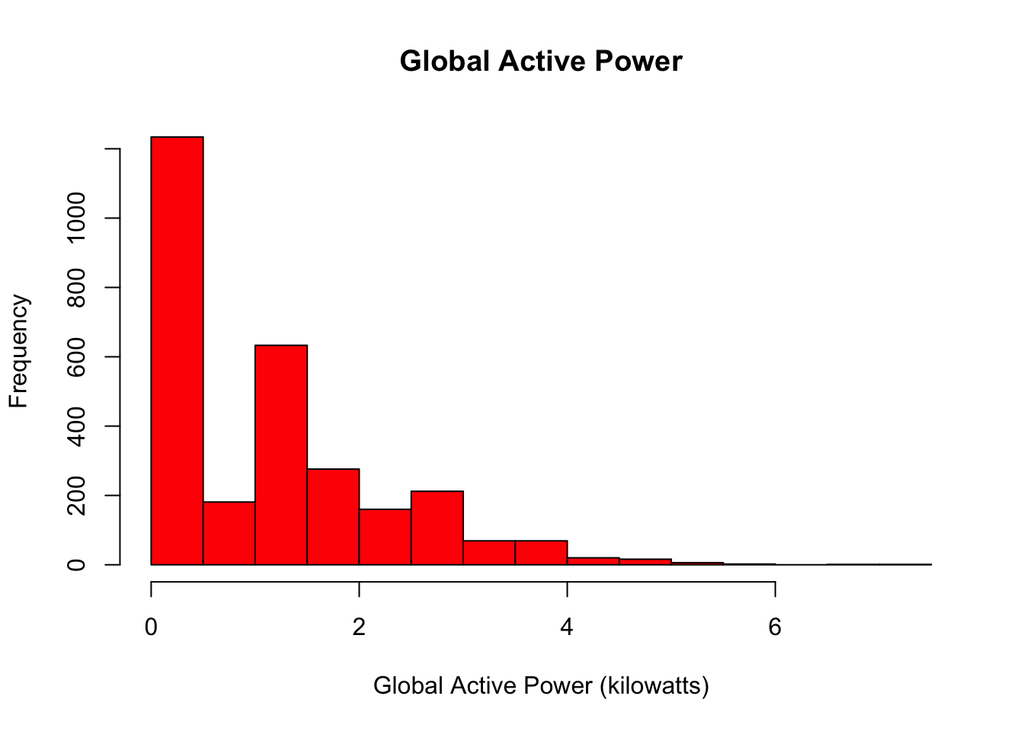

2. Plot 2 - Time series plot of global minute-averaged active power (in kilowatt) Merge ‘Date’ and ‘Time’ ‘Date_Time’ column for use of time format

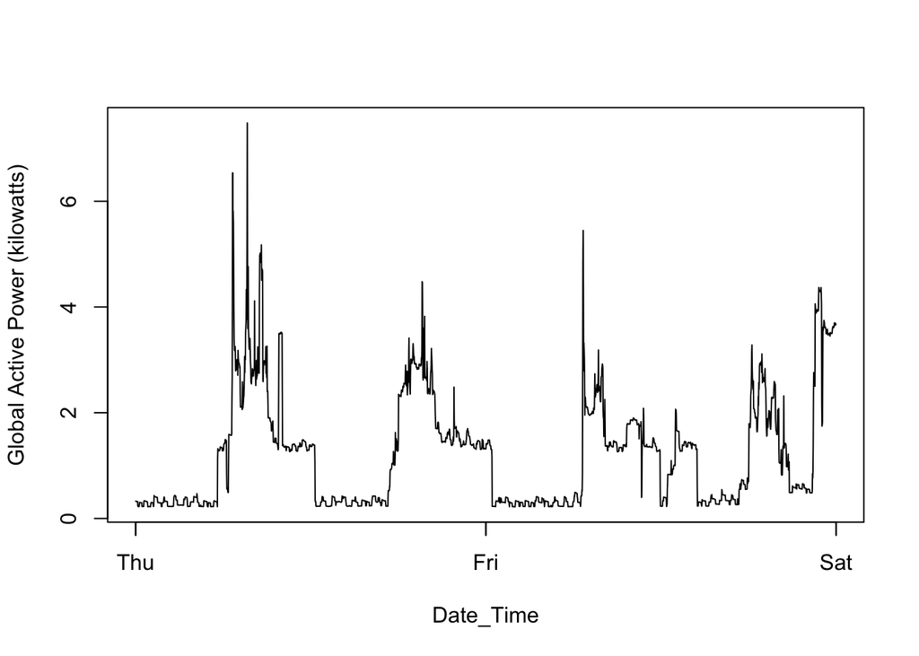

```r
#plot2.png
Date_Time <- paste(Date, Time)
Date_Time <- strptime(Date_Time, "%d/%m/%Y %H:%M:%S")

plot(x = Date_Time, y = Global_active_power, type = "l",
     ylab = "Global Active Power (kilowatts)")
```

3. Plot 3 - Time series plot of energy usage across various sections of the house.

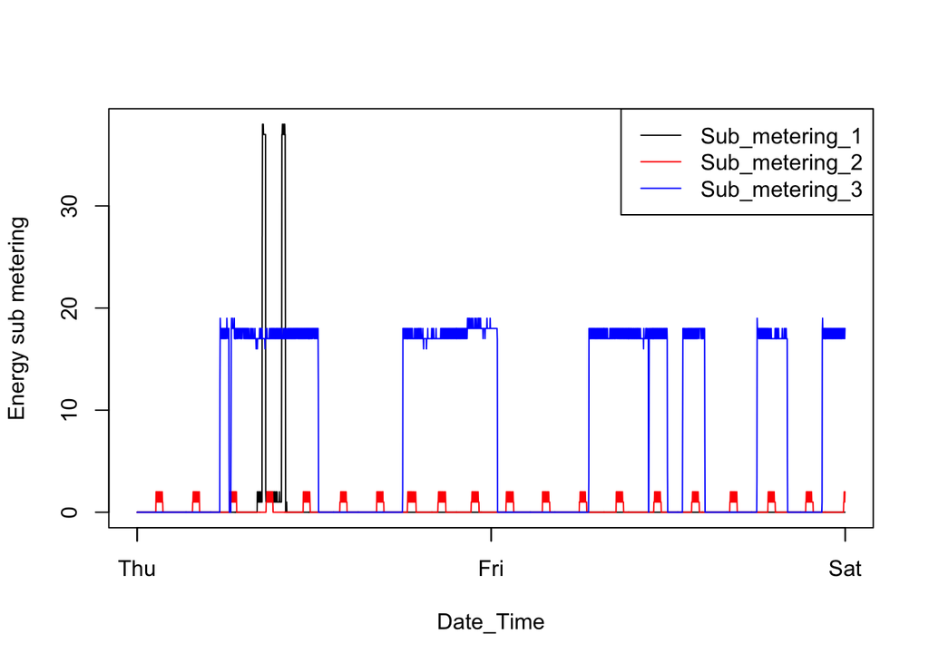

```r
#plot3.png
plot(x = Date_Time, y = Sub_metering_1,  type = "l", ylab = "Energy sub metering")
lines(x = Date_Time, y = Sub_metering_2, col = "red")
lines(x = Date_Time, y = Sub_metering_3, col = "blue")
legend("topright", legend = c("Sub_metering_1", "Sub_metering_2", "Sub_metering_3"),
       lty = 1, col = c("black", "red", "blue"))
```

4. Plot 4 - Combined Time Series Plots

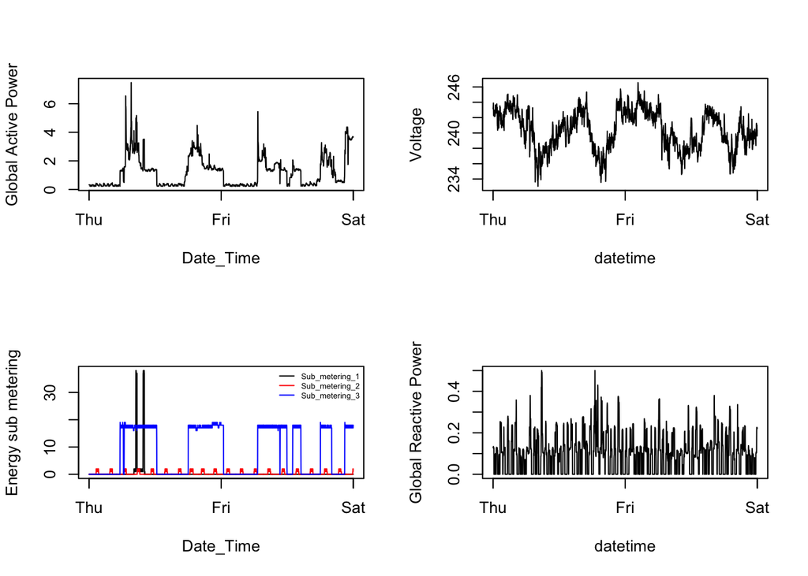

```r
#plot4.png
## Split the device into four plotting regions
par(mfcol = c(2, 2))

## 'Global Active Power' vs 'Time' Plot
plot(x = Date_Time, y = Global_active_power, type = "l",
     ylab = "Global Active Power")

## 'Energy sub metering' vs 'Time' Plot
plot(x = Date_Time, y = Sub_metering_1,  type = "l", ylab = "Energy sub metering")
lines(x = Date_Time, y = Sub_metering_2, col = "red")
lines(x = Date_Time, y = Sub_metering_3, col = "blue")
legend("topright", legend = c("Sub_metering_1", "Sub_metering_2", "Sub_metering_3"), lty = 1, bty = "n", col = c("black", "red", "blue"), cex=.5 )

## 'Voltage' vs 'Time' Plot
plot(x = Date_Time, y = Voltage, type = "l", xlab = "datetime",
     ylab = "Voltage")

# 'Global_reactive_power' vs 'Time' Plot
plot(x = Date_Time, y = Global_reactive_power,
     type = "l", xlab = "datetime", ylab = "Global Reactive Power")
```